# Agenda

1. Problem
2. EDA
3. Solution
   - Base Model
   - Modeling fun with PyCaret
4. Conclusion

# 1. Problem

- Regression
- Target: **normalized losses** ~ "*relative average loss payment per insured vehicle year.*" ([UCI](https://archive.ics.uci.edu/ml/datasets/Automobile))
- Metric: MSE

# 2. EDA

We are looking at a data set about old cars. The original target was probably the price. Here we'll try to predict normalized-losses. Note, the data set is very small. After cleaning there are only 164 rows left (far too less in a production-like environment).

```python
df = pd.read_csv("data/imports-85.data", header=None, names=columns)
df = clean_df(df)
df.head(3)
```

```
164 rows (80.0%) left after preprocessing
```

|  | normalized-losses | make | fuel-type | aspiration | num-of-doors | body-style | drive-wheels | engine-location | wheel-base | length | width | height | curb-weight | engine-type | num-of-cylinders | engine-size | fuel-system | bore | stroke | compression-ratio | horsepower | peak-rpm | city-mpg | highway-mpg | price |
| --- | --- | --- | --- | --- | --- | --- | --- | --- | --- | --- | --- | --- | --- | --- | --- | --- | --- | --- | --- | --- | --- | --- | --- | --- | --- |
| 3 | 164.0 | audi | gas | std | four | sedan | fwd | front | 99.8 | 176.6 | 66.2 | 54.3 | 2337 | ohc | four | 109 | mpfi | 3.19 | 3.4 | 10.0 | 102.0 | 5500.0 | 24 | 30 | 13950.0 |
| 4 | 164.0 | audi | gas | std | four | sedan | 4wd | front | 99.4 | 176.6 | 66.4 | 54.3 | 2824 | ohc | five | 136 | mpfi | 3.19 | 3.4 | 8.0 | 115.0 | 5500.0 | 18 | 22 | 17450.0 |
| 6 | 158.0 | audi | gas | std | four | sedan | fwd | front | 105.8 | 192.7 | 71.4 | 55.7 | 2844 | ohc | five | 136 | mpfi | 3.19 | 3.4 | 8.5 | 110.0 | 5500.0 | 19 | 25 | 17710.0 |

## A Look at Distributions and Relations

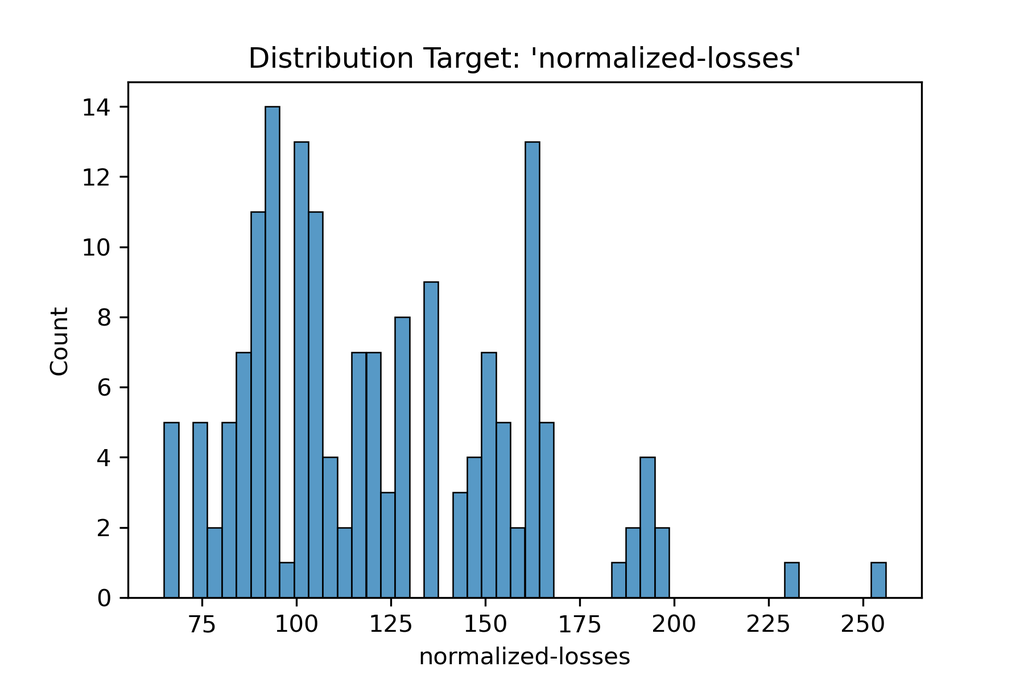

```python
Image("img/target_dist.png", width = 600)
```

- Not much data!
- Target variable almost right skewed distribution

```
Pairplotted Relations I
```

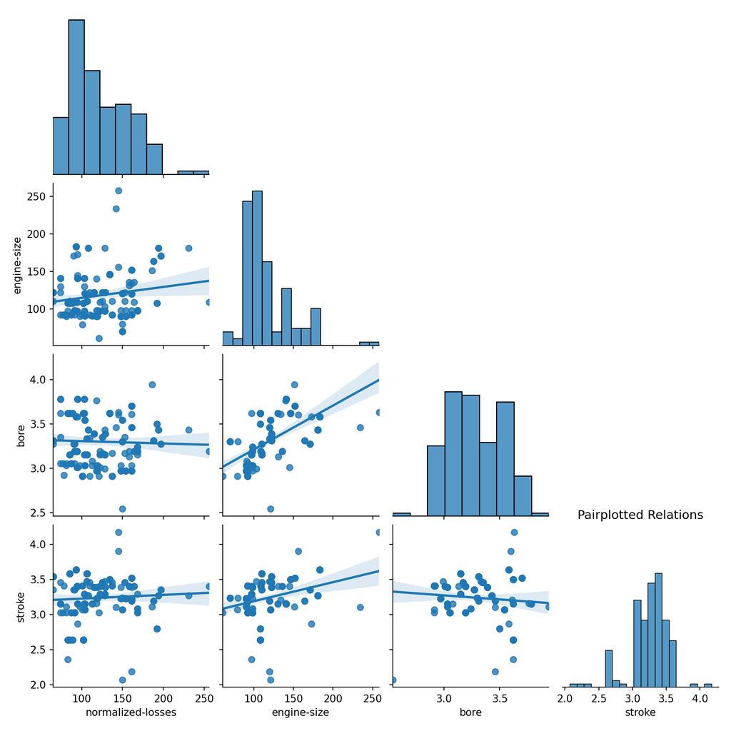

```python
print("Pairplotted Relations I")
Image("img/pair_plot_2.png", width = 500)
```

- Small example of features
- No clear simple linear relation with normalized losses
- Spread getting bigger at normalized losses > 160

```
Pairplotted Relations II
```

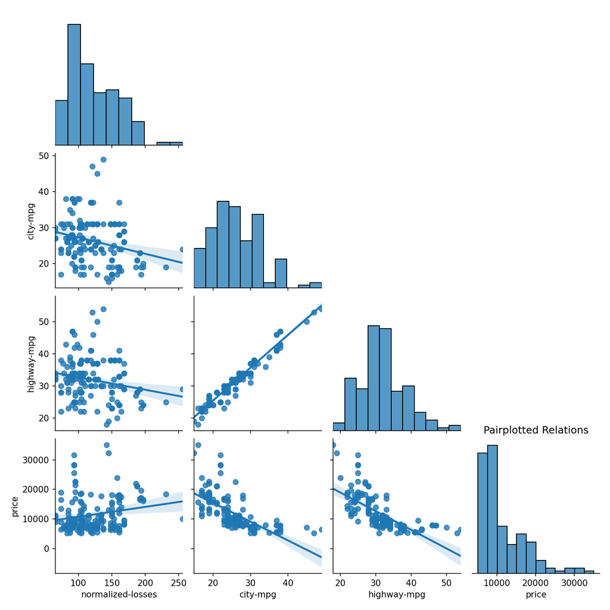

```python
print("Pairplotted Relations II")
Image("img/pair_plot_4.png", width = 500)
```

- String linear relation between a view features (makes sense between *-mpg)
- Multicollinearity

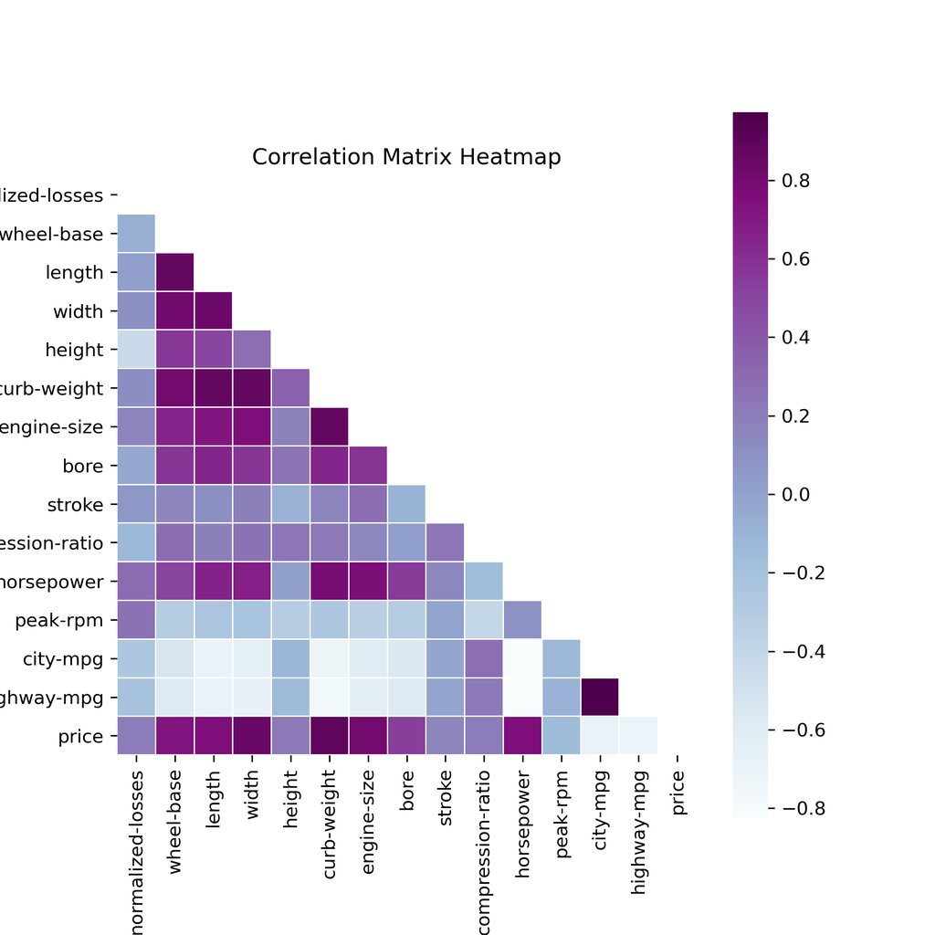

```python
Image("img/correlation_heatmap.png", width = 600)
```

- Strong positiv & strong negative correlations between some features
- Multicollinearity

# 3. Solution

We'll create a base model without further preprocessing, thereby ignoring the flaws we just found. After that we'll try a model build with PyCaret.

```python
print('Data for Modeling: ' + str(data.shape))
print('Unseen Data For Predictions: ' + str(data_unseen.shape))
```

```
Data for Modeling: (148, 25)
Unseen Data For Predictions: (16, 25)
```

## Base Model

Let's consider continuous variables only (fast).

```python
model = LinearRegression().fit(X_train, y_train)
summary(model, X_train, y_train)
```

```
Call:
lm(formula = normalized-losses ~ wheel-base + length + width + height + curb-weight + engine-size + bore + stroke + compression-ratio + horsepower + peak-rpm + city-mpg + highway-mpg + price)

                       Coefficients  Std. Error  t value  Pr(>|t|)
0         (Intercept)      573.8657     214.309    2.678     0.008
1          wheel-base        0.5757       1.331    0.433     0.666
2              length        0.2323       0.677    0.343     0.732
3               width       -1.4625       3.441   -0.425     0.672
4              height       -7.5976       1.692   -4.491     0.000
5         curb-weight        0.0192       0.022    0.858     0.392
6         engine-size        0.0765       0.244    0.313     0.755
7                bore      -30.2625      14.769   -2.049     0.042
8              stroke      -10.7359      10.732   -1.000     0.319
9   compression-ratio        0.1486       1.073    0.138     0.890
10         horsepower       -0.0592       0.254   -0.233     0.816
11           peak-rpm        0.0076       0.009    0.857     0.393
12           city-mpg       -4.8482       2.196   -2.208     0.029
13        highway-mpg        3.8132       1.961    1.944     0.054
14              price        0.0005       0.001    0.392     0.696

R squared:  0.3388
```

```python
MSE = round(mean_squared_error(y_test, model.predict(X_test)),2)
RMSE = round(mean_squared_error(y_test, model.predict(X_test), squared=False),2)

print(f"MSE: {MSE}",f"RMSE: {RMSE}", sep="\n")
```

```
MSE: 605.04
RMSE: 24.6
```

Considering that we did this just quick and dirty, an RMSE of 24.6 seems not too bad. Right? Let's see some pictures.

### Prediction Distributions

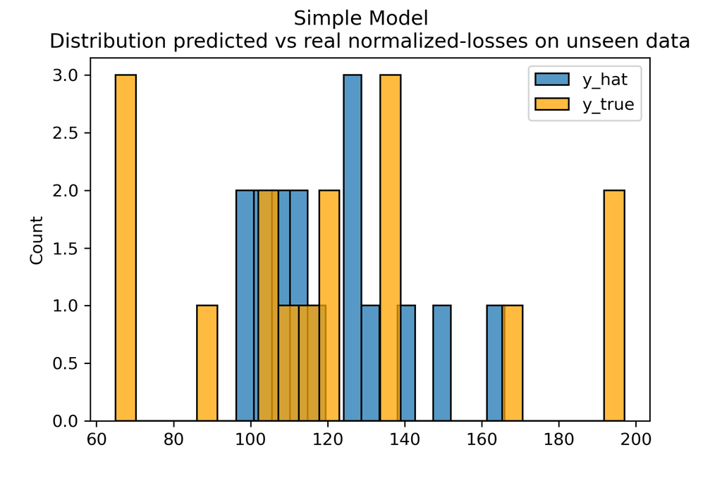

```python
Image("img/dist_pred_vs_real_unseen.png", width = 600)
```

- Very small validation set
- Looks "OK-ish" though

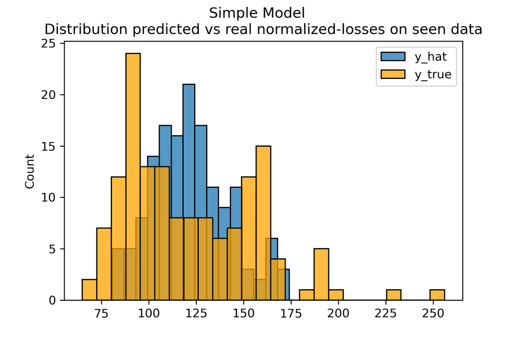

```python
Image("img/dist_pred_vs_real_seen.png", width = 600)
```

- predictions on training data
- model assumes target normaly distributed

## Modeling fun with PyCaret

Instead of dealing with issues like strong correlations between features manually and doing a parameter optimization in a similar fashion, let's figure out if PyCaret can deal with that out of the box.

### Prepare the stage

```python
params = {
    "data": data,
    "target": "normalized-losses",
    "train_size": 0.8,
    "categorical_features": [c for c in cols[1:] if c not in numerics],
    "remove_multicollinearity": True,
    "verbose": False,
    "silent": True,
    "fold": 10,
    "session_id": seed,
}
regr = setup(**params)
```

So easy to setup 🙂

### Find best models (lowest MSE)

```python
top3 = compare_models(n_select = 3,sort = 'MSE',
                      exclude=['huber','lar','par', 'knn', 'llar', 'br', 'en','lr'],
                      verbose=False)
```

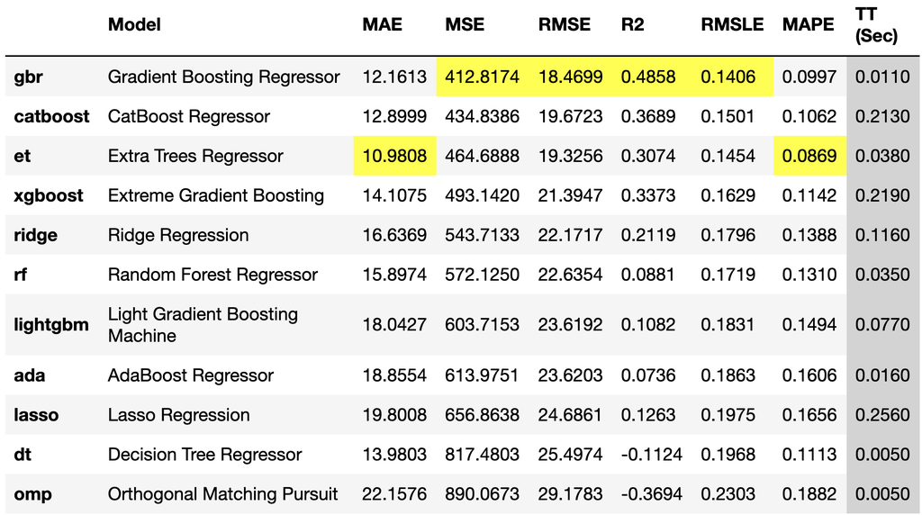

```python
Image("img/top3.png", width = 600)
```

Out of the box state of the art models seem to perform well.

### Stack them together

```python
stacker = stack_models(estimator_list = top3[1:], meta_model = top3[0], verbose=False)
```

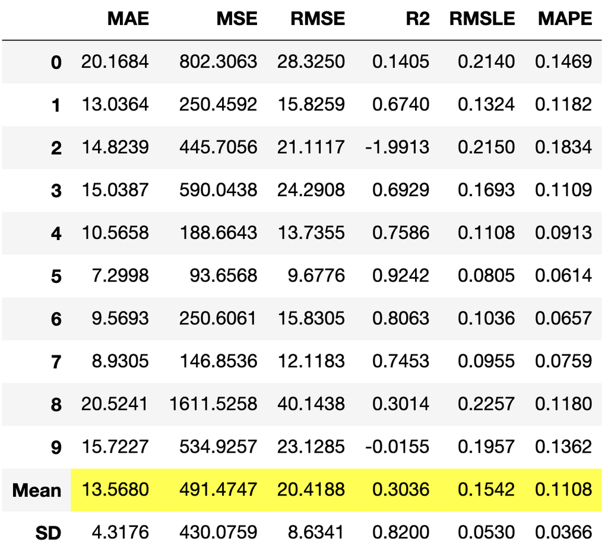

```python
Image("img/stacked.png", width = 400)
```

Quite a high standard deviation for MSE within our ensemble.

### Tune ensemble model

```python
tuned_best_model_optuna = tune_model(
    stacker,
    search_library="tune-sklearn",
    search_algorithm="optuna",
    n_iter=3,
    optimize = "MSE",
    verbose=False
)
```

```
[I 2021-05-02 12:01:34,655] A new study created in memory with name: optuna
```

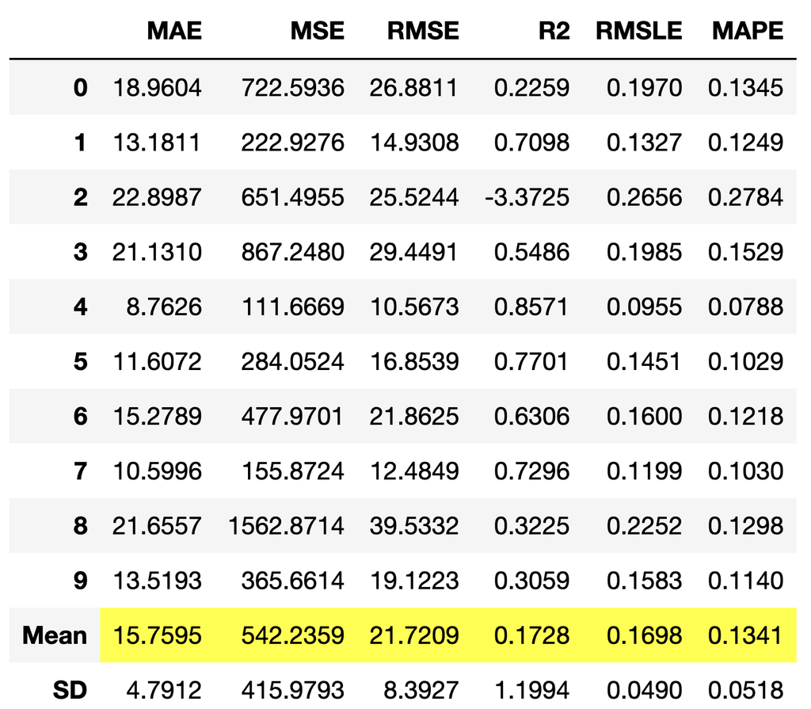

```python
Image("img/tuned.png", width = 400)
```

- Instead of going through lots of bad hyperparameter settings via RandomizedSearchCV() or GridSearchCV(), we did a Bayesian optimization with `tune-sklearn`. Pretty cool & pretty fast 😉.
- Note, that the standard deviation for MSE slightly decreased.
- Only 3 iterations to avoid further overfitting

### Prediction Error

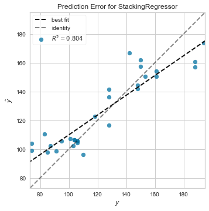

```python
plot_model(tuned_best_model_optuna, 'error')
```

- No exact match between real normalized losses and predicted ones (y_hat)
- Error increases with distance from normalized losses of 130

### Residuals

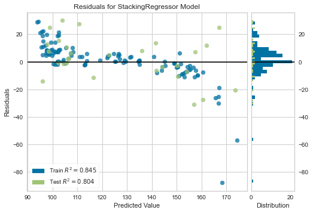

```python
plot_model(tuned_best_model_optuna, 'residuals')
```

- similar to previous graph:
  - the bigger the target value, the greater the error
- fit seems ok .84 vs .80

### Prediction Distributions

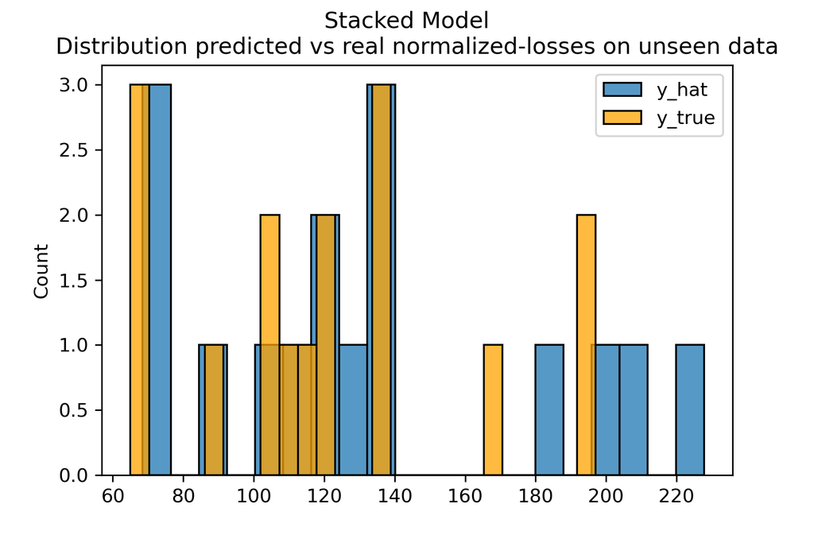

```python
Image("img/dist_pred_vs_real_unseen_stacked.png", width = 600)
```

- Stacked model slightly better performance than base model on new data.
- Errors seem to increase with value of normalized losses

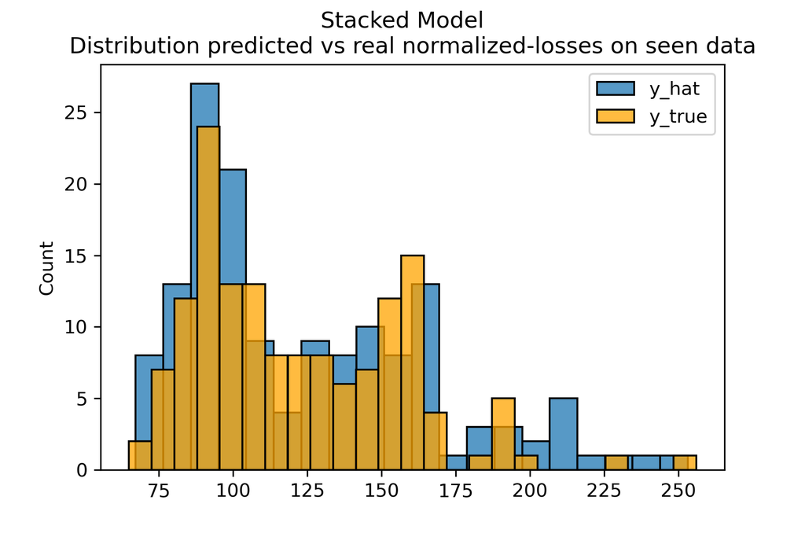

```python
Image("img/dist_pred_vs_real_seen_stacked.png", width = 600)
```

- Predictions on seen data pretty close to y_true

# Conclusion

- We worked with an **extremely small data set**. This may be suffient in a research setting. However, in practice it is recommended to work with as much data as possible (#rows > 100k). Hence, in business cash matters, not the p-value.
- We used **very clean data**. In reality we'd have spent several days just for preprocessing 😉.
- **PyCaret was fun!** Incredible how much time we could save by using this framework. I'll work more with it.
- 감사합니다 🙂